# COMM 3710: Introduction to Statistics; Descriptive Statistics

# Why Statistics?

Statistics is a way of…

- organizing,
- describing,
- and making inferences from data.

Statistics is fundamental to scientific processes. As you grow accustomed and practiced at thinking statistically, you will find yourself interpreting and evaluating claims that people make more analytically and critically.

Sometimes math anxiety can interfere with the goal of conceptual understanding of statistics—this is based on the belief that stats is about numbers and math. But, stats is not solely about math and numbers.

> Statistics is more of a language by which we can communicate empirical evidence.

As we would when learning a new language, we’re going to start by learning some vocabulary.

Before we jump into learning some basic statistics this week, let’s talk about why statistics might be useful for your future careers.

In today’s media environment, data are used in a myriad of ways. We see data-driven reporting on everything from politics ([civic-minded folks, click here](https://projects.fivethirtyeight.com/2020-election-forecast/)) to sports ([baseball fans, click here](http://projects.fivethirtyeight.com/complete-history-of-mlb/#); [basketball fans, click here](http://projects.fivethirtyeight.com/complete-history-of-the-nba/#cavaliers); [football fans, click here](http://fivethirtyeight.com/features/the-nfls-most-run-heavy-and-pass-happy-teams/)). Such data journalism has become prevalent in the online media environment and some familiarity with the statistics and tools used in this area is vital.

However, although most employers would like you to be familiar with basic statistics and statistical tools, they do not expect you will be an expert in data analysis or statistics!

[Read this article and watch the video embedded in it](https://journalistsresource.org/studies/society/news-media/research-chat-new-york-times-sarah-cohen-state-data-journalism-what-reporters-need-know/). It will give you a sense of what data journalism is about. The article is an interview with Sarah Cohen, a reporter from The New York Times, and the video in the article shows her and a faculty member, Susan McGregor, from the Columbia Journalism School, discussing and demystifying data journalism.

Back to top

# The “Central Dogma” of Statistics

The figure below illustrates the “central dogma” of statistics. Using statistics, we seek to learn more about the **population** of interest. However, we rarely (if ever!) have access to every unit in a population. Therefore, we take a representative sample, or a representative subset of the population, and use this sample to **describe** (descriptive statistics) and make **inferences/predictions/generalizations** (inferential statistics) about the population.

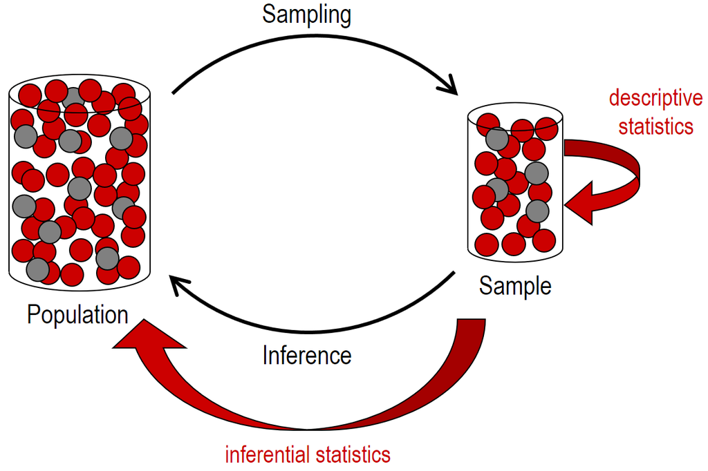

But what exactly is a statistic?

Review the figure above. The central dogma has a population and a sample. **Statistics are associated with samples** while **parameters are associated with populations**.

> We use statistics from a sample to estimate (infer) parameters in a population.

## Parameter

- number that describes the population (e.g., mean, standard deviation, variance, etc.)
- parameters are often unknown because we cannot directly examine the entire population of interest!

Back to top

## Statistic

- number that can be computed from sample data (e.g., mean, standard deviation, variance, etc.)
- we use statistics in a sample to estimate parameters in a population!
- for example, we can calculate the mean age in a sample and use this statistic to estimate the mean age in the population.

Back to top

# Categories of Statistics

In general, there are two types of statistics: **descriptive** and **inferential statistics**. The figure below highlights the differences between these two types and provides examples of questions that researchers might ask using descriptive and inferential statistics. In the next sections, we will discuss these types of statistics in more detail.

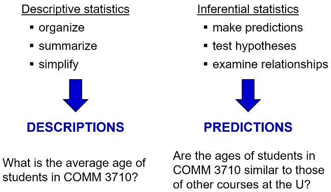

Back to top

# Descriptive Statistics: An Example

This week, we will discuss descriptive statistics. We will add inferential statistics next week.

Let’s begin with an illustration of the utility of descriptive statistics…

The table below shows IQ scores of students in Class A and Class B. Which class is smarter?

| Class A | Class B |
| --- | --- |
| 102 | 127 |
| 128 | 131 |
| 131 | 96 |
| 98 | 80 |
| 140 | 90 |
| 93 | 120 |
| 110 | 109 |
| 115 | 162 |
| 109 | 103 |
| 89 | 111 |
| 106 | 109 |
| 119 | 87 |
| 97 | 105 |

It is difficult to tell which class is smarter because it is difficult for us to process the information provided in the table. However, we can use descriptive statistics (in this case, the mean) to summarize these data and help us answer the question.

As it turns out, the students in Class A and B have similar IQs on average!

Back to top

# Types of Descriptive Statistics

We can use descriptive statistics to:

1. Organize data
2. Summarize data

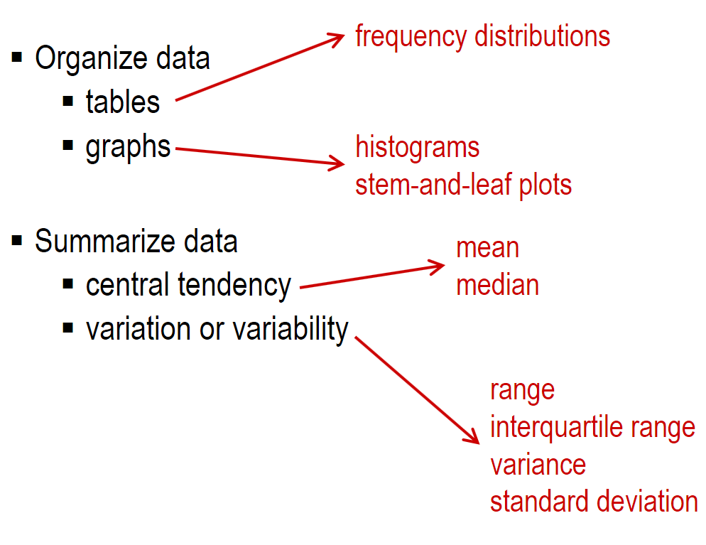

## Organizing Data

A frequency distribution is a description of the number of times the various attributes of a variable are observed in a sample. This can be show in tables or graphs (histograms, stem-and-leaf plots). Watch the short video below for an explanation of **frequency distribution tables, histograms, and stem-and-leaf plots**.

[video not shown]

Back to top

## Summarizing Data

To summarize data, we often think about **central tendency** and **variability**.

Central tendency refers to the middle values of groups, while variability refers to the spread of the data in the groups.

### Central Tendency

#### Mean

The mean ($\bar{x}$) is the “average” of the data points of a variable. In our example of IQ scores in Class A and Class B (above), we calculate the mean by adding all the scores in each class and dividing by the number of students in each class. In mathematical notation, the formula for calculating a mean would be:

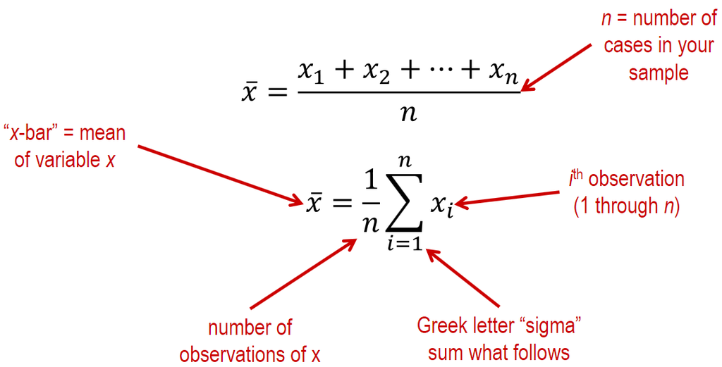

You can think of the mean as a **balance point**.

Imagine each person’s score is a 1-lb weight placed at the score’s position on a see-saw. Let’s say we have a 200-meter long see-saw and the mean is 110 m. And we have 3 people in our sample with scores of 93 m, 106 m, and 131 m.

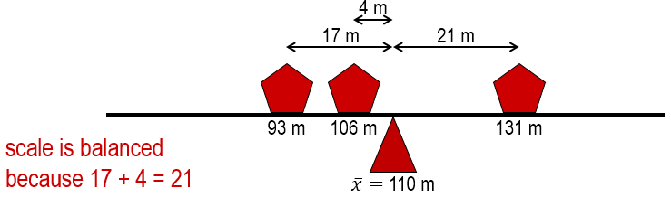

Because of this, the mean can be badly affected by outliers, which can make the mean a poor measure of central tendency.

For example, the mean of annual income in the U.S. (the point marked by the red triangle in the figure below) is skewed by the very rich among us, e.g., BIll Gates (outliers)!

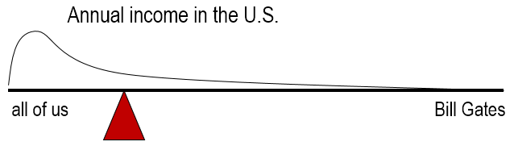

Back to top

#### Median

The median is the second measure of central tendency that we will discuss. The median is the middle value in a ranked set of values. This middle value divides the ranked values into two equal halves.

The median is also known as the **50th percentile**. When the data are ranked, the median (or 50th percentile) is the point at which 50% of the cases are above and 50% of the cases are below. Watch the video below for an explanation of how to calculate the median and the relationship between the mean and median.

[video not shown]

Back to top

### Variability

We will look at 4 different measures of the spread (or variability) of data: **range, interquartile range, variance, and standard deviation**.

#### Range

The range is the spread between the lowest and highest values of a variable.

To calculate the range, we simply subtract the lowest from the highest value of the variable. Using the example of IQ scores of students in Class A and Class B, we can calculate a range for each class.

| Class A | Class B |
| --- | --- |
| 102 | 127 |
| 128 | 131 |
| 131 | 96 |
| 98 | 80 |
| 140 | 90 |
| 93 | 120 |
| 110 | 109 |
| 115 | 162 |
| 109 | 103 |
| 89 | 111 |
| 106 | 109 |
| 119 | 87 |
| 97 | 105 |

**Class A**
$$Range = 140-89 = 51$$

**Class B**
$$Range = 162-80 = 82$$

Back to top

#### Interquartile Range (IQR)

First, let’s define quartiles. **Quartiles are values that divide a list of numbers into 4 equal parts**.

In the example below, let’s assume we have a sequential list of numbers that ranges from 0 to 100. The first quartile ($Q_1$, which is also called the 25th percentile) is 25. The second quartile ($Q_2$, aka 50th percentile) is 50. $Q_2$ is special–it is also the median! The third quartile ($Q_3$, aka 75th percentile) is 75.

Now that we know what a quartile is, we can define the **interquartile range (IQR)**. This is the distance or range between $Q_3$ and $Q_1$. To calculate this, we use the formula:
$$IQR = Q_3 - Q_1$$

We use the IQR to define outliers (very high or very low values) in our data. An outlier is any value outside the lower or upper limits. These limits are determined using the following formulae (also shown in the figure below):

Lower limit $= Q1 - 1.5 \times (IQR)$

Upper limit $= Q3 + 1.5 \times (IQR)$

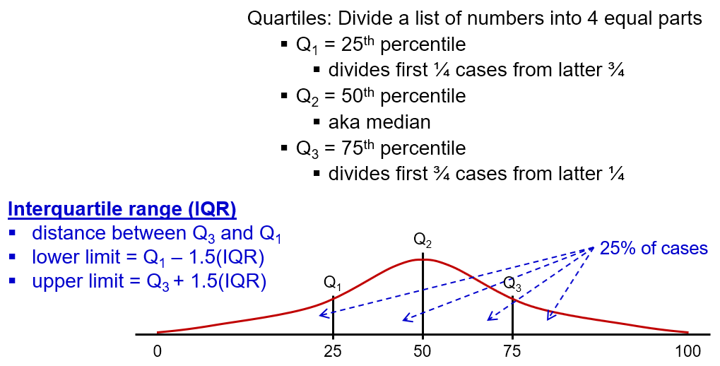

Back to top

#### Variance

Variance measures the spread or dispersion of individual cases around the mean in a variable

When the variance is larger, this means that individual cases are farther away from the mean. A smaller variance, on the other hand, means that individual cases are closer to the mean.

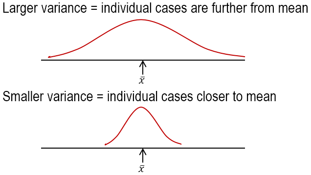

To calculate variance, we use the following formula:

$$Variance = \frac{1}{n-1}\sum^{n}_{i = 1}(x_i - \bar{x})^2$$
Watch the video under the *Standard Deviation* tab for step-by-step instructions on how to calculate variance and standard deviation.

Back to top

#### Standard Deviation

The standard deviation is another measure of the spread of data around the mean. However, unlike variance, standard deviation is the average deviation of the cases from the mean.

It is closely related to variance; to calculate standard deviation, we simply take the square root of the variance:

$$SD = \sqrt{\frac{1}{n-1}\sum^{n}_{i = 1}(x_i - \bar{x})^2}$$

In the video below, we will work through an example step-by-step and calculate its variance and standard deviation.

[video not shown]

Back to top

# Graphical Summaries of Data

Next, let’s look at how we can show all the descriptive statistics that we’ve just learned about in a single graph.

The **box plot** is a very useful figure as it can be used to show almost all descriptive statistics in one figure!

In a box plot, we can show…

- $Q_1$ and $Q_3$
- mean ($\bar{x}$)
- median ($Q_2$)
- range
- outliers

[figure not shown]

[figure not shown]

Back to top